# ESD Data Science Graduate Programme Exercise

# Part One

We are interested in creating statistical models that will predict GDP, using the explanatory variables provided in the data set (Consumer Prices, Unemployment Rate (UNEM), Gross Fixed Capital Formation (GFCF), Final Consumption Expenditure by General Government (GovExp) and Final Consumption Expenditure by Household (HouseExp). Before this is done, Exploratory Data Analysis is conducted on the provided data set.

## Exploratory Data Analysis

Exploration of the data set informs us that the data needs to be cleaned before it can be used to generate summary statistics, create visualizations and perform model training. Examples of miscellaneous errors in the data are:

- Missing Values in each of the Variables
- The addition of zeroes onto the end of selected values in the data for each of the variables

These errors are cleaned and handled before EDA is continued below.

Summary Statistics

| Variable | N | Mean | Std. Dev. | Min | Pctl. 25 | Pctl. 75 | Max |
| --- | --- | --- | --- | --- | --- | --- | --- |
| GDP | 121 | 3694302 | 773383 | 2347597 | 2904913 | 4446289 | 4650164 |
| GFCF | 121 | 588799 | 177521 | 274432 | 380957 | 751762 | 815427 |
| UNEM | 121 | 25 | 4 | 17 | 23 | 27 | 35 |
| ConsumerPrices | 121 | 62 | 24 | 26 | 42 | 80 | 114 |
| GovExp | 121 | 701077 | 157697 | 464938 | 524441 | 853104 | 921594 |
| HouseExp | 121 | 2321628 | 575017 | 1341416 | 1742516 | 2833132 | 3100030 |

The Summary Statistics Table of the data above shows that the errors and missing values that were discovered in the data have been handled.

### Time Series Visualisations

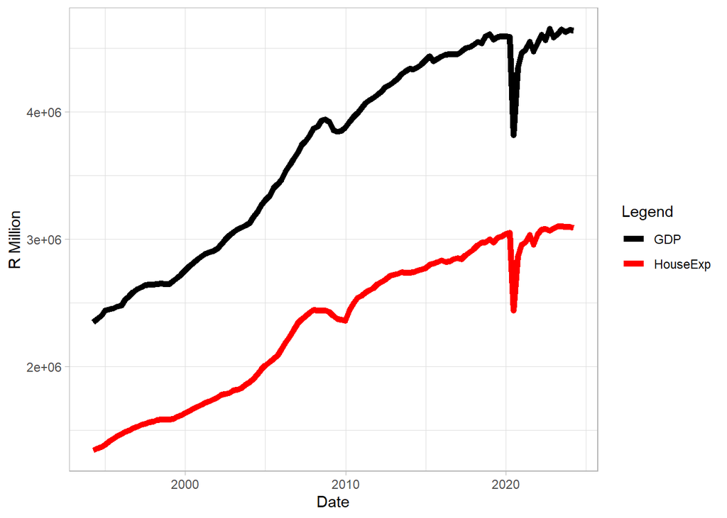

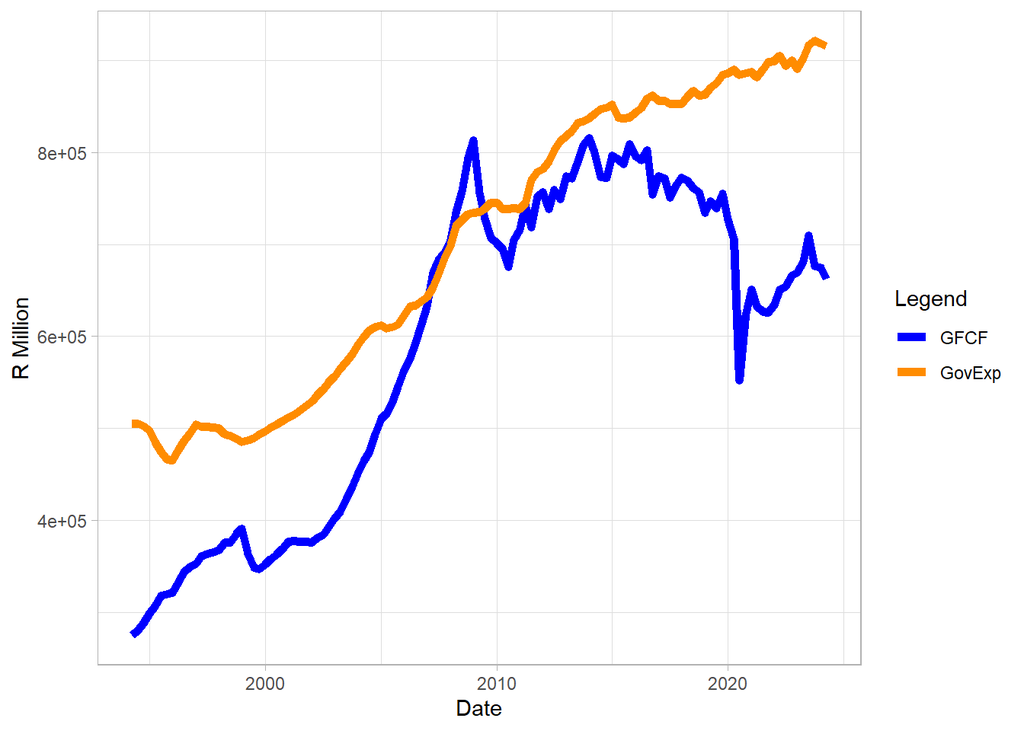

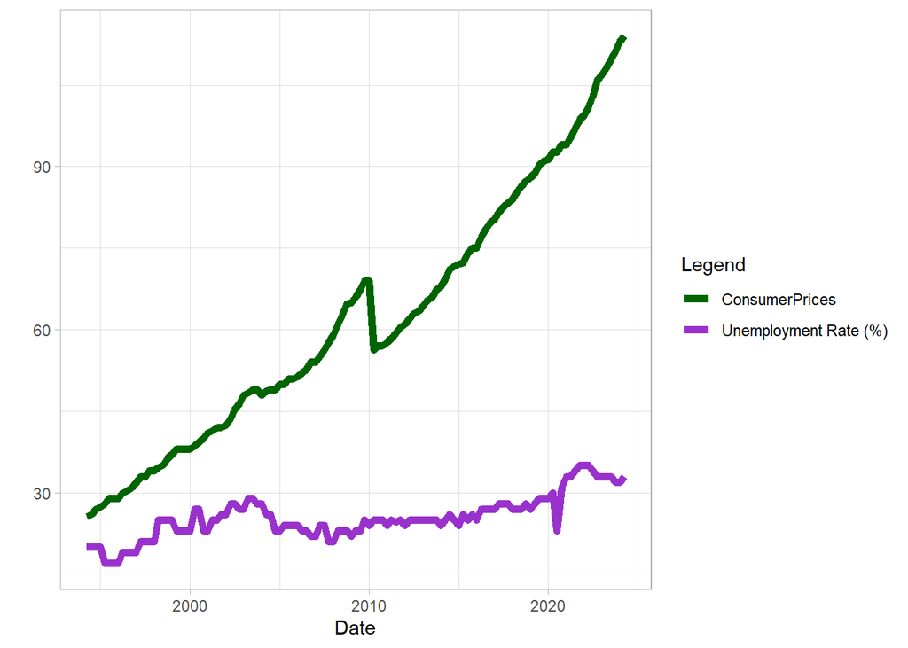

### Comparative Exploratory Data Analysis

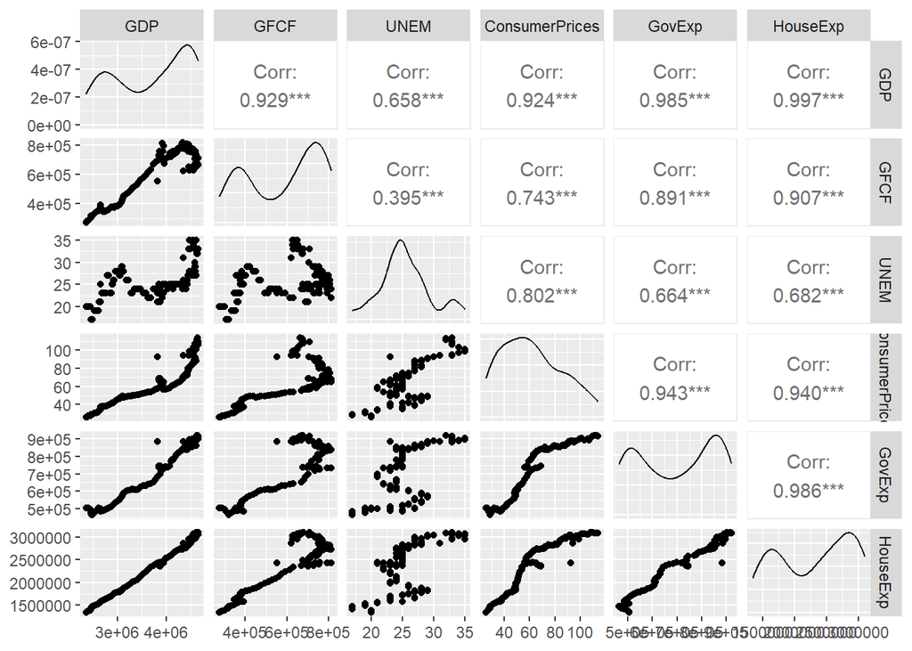

# Part Two

## Model Training

#### Simple Linear Regression Model

|  | (1) |
| --- | --- |
| (Intercept) | 461298.633 |
|  | s.e. = 46112.526 |
|  | p = <0.001 |
| GFCF | 0.745 |
|  | s.e. = 0.079 |
|  | p = <0.001 |
| UNEM | 7227.716 |
|  | s.e. = 1854.656 |
|  | p = <0.001 |
| ConsumerPrices | -815.341 |
|  | s.e. = 729.462 |
|  | p = 0.267 |
| GovExp | 0.476 |
|  | s.e. = 0.143 |
|  | p = 0.001 |
| HouseExp | 1.002 |
|  | s.e. = 0.052 |
|  | p = <0.001 |
| Num.Obs. | 91 |
| R2 | 0.998 |
| R2 Adj. | 0.998 |
| AIC | 2162.1 |
| BIC | 2179.7 |
| Log.Lik. | -1074.047 |
| F | 9482.721 |
| RMSE | 32330.82 |

If we fit a simple linear regression model to the data using all the explanatory variables, the table above gives the output of the model and we can infer certain things about both the data and the model. The regression coefficients tell us the impact of a unit change in the explanatory variables on the GDP. A unit change in the Government Expenditure results in a 0.476 change in the GDP. Alternatively, a unit change in the unemployment rate results in a 7227.716 change in the GDP. The R^2 value informs us on how well the model predicts GDP in sample. At 99.8%, this suggests that the model is a great fit and the explanatory variables predict GDP well. The p-values suggest that some of the explanatory variables should not be included in the model, namely the Consumer Price Index. Step-wise Regression is implemented to determine the optimal number of explanatory variables to use in the model. Some of the variables might not have a great impact on improving the fit of the model to the data.

|  | (1) |
| --- | --- |
| (Intercept) | 500905.749 |
|  | s.e. = 29550.385 |
|  | p = <0.001 |
| GFCF | 0.790 |
|  | s.e. = 0.068 |
|  | p = <0.001 |
| UNEM | 6591.079 |
|  | s.e. = 1767.585 |
|  | p = <0.001 |
| GovExp | 0.404 |
|  | s.e. = 0.128 |
|  | p = 0.002 |
| HouseExp | 0.980 |
|  | s.e. = 0.048 |
|  | p = <0.001 |
| Num.Obs. | 91 |
| R2 | 0.998 |
| R2 Adj. | 0.998 |
| AIC | 2161.4 |
| BIC | 2176.5 |
| Log.Lik. | -1074.711 |
| F | 11818.826 |
| RMSE | 32567.55 |

Step-wise regression shows that one explanatory variable can be removed from the model (ConsumerPrices), while maintaining the same fit of model (as seen in the R<sup>2 values and adjusted R^2 values</sup> remaining the same). The resultant fit of the simple linear regression model suggest that a more complicated model is not necessary as the trade-off in complexity and efficiency would not greatly improve on the simple model fit to the data.

#### Regression Neural Network Model

It would be interesting to fit a neural network to the data, merely to compare the results. I do not think doing so would be necessary as the simple linear regression model is already a great fit and and predictor of GDP as seen above. Also, time-constraints do not allow.